# Lab 3 - Individual 2

Samuel Reinart

3/2/2021

## Data Exploration

```r
aveEdu <- data %>%
  filter(!is.na(`Marital status`)) %>%
  group_by(`Marital status`) %>%
  summarize(`Average years of education` = mean(`Highest year of school completed`, na.rm=TRUE)) %>%
  arrange(desc(`Average years of education`))
aveEdu
```

```
## # A tibble: 6 x 2
##   `Marital status` `Average years of education`
##   <chr>                                   <dbl>
## 1 No answer                                15.5
## 2 Never married                            13.4
## 3 Divorced                                 13.1
## 4 Married                                  13.0
## 5 Separated                                11.9
## 6 Widowed                                  11.2
```

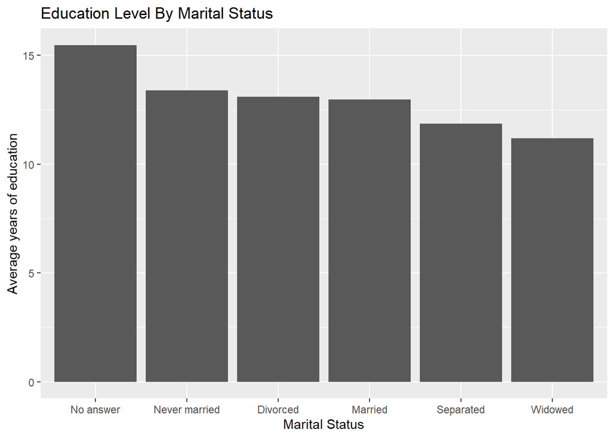

```r
data %>%
  filter(!is.na(`Marital status`)) %>%
  group_by(`Marital status`) %>%
  summarize(mean = mean(`Highest year of school completed`, na.rm=TRUE)) %>%
  ggplot(aes(x=reorder(`Marital status`, -mean), weight=mean)) +
  geom_bar() +
  labs(title="Education Level By Marital Status", x="Marital Status", y="Average years of education")
```

```r
betterEducated <- data %>%
  filter(!is.na(`Marital status`)) %>%
  group_by(`Marital status`) %>%
  filter(`Highest year of school completed` > mean(`Highest year of school completed`, na.rm=TRUE)) %>%
  ungroup()
str(betterEducated)
```

```
## tibble [30,714 x 12] (S3: tbl_df/tbl/data.frame)
##  $ Gss year for this respondent    : num [1:30714] 1972 1972 1972 1972 1972 ...
##  $ Homosexual sex relations        : chr [1:30714] "Not applicable" "Not applicable" "Not applicable" "Not applicable" ...
##  $ General happiness               : chr [1:30714] "Not too happy" "Not too happy" "Pretty happy" "Not too happy" ...
##  $ Belief in life after death      : chr [1:30714] "Not applicable" "Not applicable" "Not applicable" "Not applicable" ...
##  $ Political party affiliation     : chr [1:30714] "Ind,near dem" "Not str democrat" "Ind,near dem" "Ind,near dem" ...
##  $ Respondents income              : chr [1:30714] "Not applicable" "Not applicable" "Not applicable" "Not applicable" ...
##  $ Respondents sex                 : chr [1:30714] "Female" "Female" "Male" "Male" ...
##  $ Highest year of school completed: num [1:30714] 16 17 14 16 13 14 14 17 14 13 ...
##  $ Marital status                  : chr [1:30714] "Never married" "Married" "Never married" "Never married" ...
##  $ Ever work as long as one year   : chr [1:30714] "Not applicable" "Not applicable" "Not applicable" "Not applicable" ...
##  $ Respondent id number            : num [1:30714] 1 4 6 8 11 16 17 19 20 23 ...
##  $ Ballot used for interview       : chr [1:30714] "Not applicable" "Not applicable" "Not applicable" "Not applicable" ...
```

```r
percHappy <- data %>%
  filter(!is.na(`Marital status`)) %>%
  mutate(Happy = ifelse(`General happiness` == "Very happy" |
                        `General happiness` == "Pretty happy", "Happy", "Unhappy")) %>%
  group_by(`Marital status`) %>%
  summarize(`Percentage of Happy Partners by Marital Status` =
            100 * length(Happy[which(Happy == "Happy")]) / n()) %>%
  arrange(desc(`Percentage of Happy Partners by Marital Status`))
percHappy
```

```
## # A tibble: 6 x 2
##   `Marital status` `Percentage of Happy Partners by Marital Status`
##   <chr>                                                       <dbl>
## 1 Married                                                      86.0
## 2 Never married                                                77.2
## 3 Widowed                                                      75.4
## 4 Divorced                                                     73.8
## 5 Separated                                                    66.3
## 6 No answer                                                    59.3
```

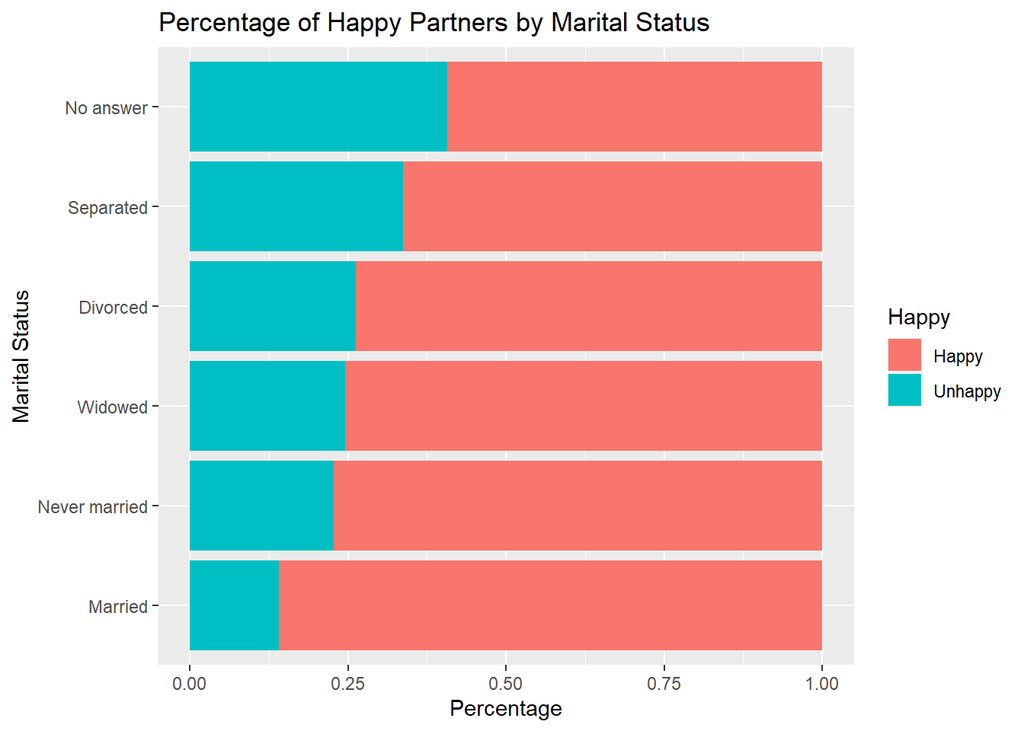

```r
data %>%
  filter(!is.na(`Marital status`)) %>%
  mutate(Happy = ifelse(`General happiness` == "Very happy" |
                        `General happiness` == "Pretty happy", "Happy", "Unhappy")) %>%
  ggplot(aes(fill=Happy, x=factor(`Marital status`, levels=pull(percHappy, `Marital status`)))) +
  geom_bar(position="fill") +
  coord_flip() +
  labs(title="Percentage of Happy Partners by Marital Status", x="Marital Status", y="Percentage")
```

As shown in the tibble and graph, respondents who were married were by far the most happy group, where 86.0% of them were happy. The next happiest group was those who never married, where 77.2% of them were happy. These two groups are probably the happiest because either they are in a good marriage, or they aren’t married to someone they don’t like. The next 2 lowest groups were previously, but no longer, married to another person. The widowed and divorced groups had happiness percentages of 75.4% and 73.8%. It is likely that the happiness of these two groups is lower because they no longer have a significant other. The next lowest group was respondents who were currently separated, of which 66.3% were happy. It makes sense that these respondents would have a greater chance of being unhappy, if they are stuck in a marriage they don’t want to be in. The group with the lowest happiness was those who gave no answer concerning their marital status, of which only 59.3% were happy.

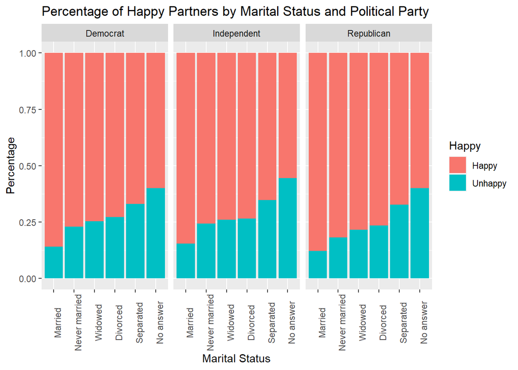

```r
ind <- c("Independent", "Ind,near rep", "Ind,near dem")
rep <- c("Strong republican", "Not str republican")
dem <- c("Strong democrat", "Not str democrat")
parties <- c(ind, rep, dem)

data %>%
  filter(!is.na(`Marital status`)) %>%
  filter(`Political party affiliation` %in% parties) %>%
  mutate(Happy = ifelse(`General happiness` == "Very happy" |
                        `General happiness` == "Pretty happy", "Happy", "Unhappy")) %>%
  mutate(Party = ifelse(`Political party affiliation` %in% ind, "Independent",
                 ifelse(`Political party affiliation` %in% rep, "Republican", "Democrat"))) %>%
  ggplot(aes(fill=Happy, x=factor(`Marital status`, levels=pull(percHappy, `Marital status`)))) +
  geom_bar(position="fill") +
  labs(title="Percentage of Happy Partners by Marital Status and Political Party",
       x="Marital Status", y="Percentage") +
  theme(axis.text.x = element_text(angle=90)) +
  facet_wrap(~ Party)
```

```r
data %>%
  filter(!is.na(`Marital status`)) %>%
  filter(`Political party affiliation` %in% parties) %>%
  mutate(Happy = ifelse(`General happiness` == "Very happy" |
                        `General happiness` == "Pretty happy", "Happy", "Unhappy")) %>%
  mutate(Party = ifelse(`Political party affiliation` %in% ind, "Independent",
                 ifelse(`Political party affiliation` %in% rep, "Republican", "Democrat"))) %>%
  group_by(`Marital status`, Party) %>%
  summarize(`Percentage of group that is happy` = 100 * length(Happy[which(Happy == "Happy")]) / n(),
            .groups="drop_last") %>%
  arrange(desc(`Percentage of group that is happy`))
```

```
## # A tibble: 18 x 3
## # Groups:   Marital status [6]
##    `Marital status` Party       `Percentage of group that is happy`
##    <chr>            <chr>                                     <dbl>
##  1 Married          Republican                                 87.9
##  2 Married          Democrat                                   85.9
##  3 Married          Independent                                84.6
##  4 Never married    Republican                                 81.9
##  5 Widowed          Republican                                 78.4
##  6 Never married    Democrat                                   77.0
##  7 Divorced         Republican                                 76.6
##  8 Never married    Independent                                75.7
##  9 Widowed          Democrat                                   74.7
## 10 Widowed          Independent                                74.0
## 11 Divorced         Independent                                73.4
## 12 Divorced         Democrat                                   72.7
## 13 Separated        Republican                                 67.3
## 14 Separated        Democrat                                   66.9
## 15 Separated        Independent                                65.2
## 16 No answer        Democrat                                   60
## 17 No answer        Republican                                 60
## 18 No answer        Independent                                55.6
```

A respondent’s political party affiliation does not affect the overall trends seen in the data for the previous question. The married group was the happiest in all political parties, while those that gave no answer were the least happy. It is interesting to note, however, that overall, a larger proportion of Independents and Democrats were unhappy when compared to Republicans. As can be seen in the tibble, a greater percentage of widowed Republicans were happier when compared to never married Independents and Democrats. Divorced Republicans were happier than never married Independents, as well as widowed Independents and Democrats.

```r
data %>%
  filter(!is.na(`Marital status`)) %>%
  group_by(`Marital status`) %>%
  summarize(`Average years of education` = mean(`Highest year of school completed`, na.rm=TRUE)) %>%
  arrange(desc(`Average years of education`))
```

```
## # A tibble: 6 x 2
##   `Marital status` `Average years of education`
##   <chr>                                   <dbl>
## 1 No answer                                15.5
## 2 Never married                            13.4
## 3 Divorced                                 13.1
## 4 Married                                  13.0
## 5 Separated                                11.9
## 6 Widowed                                  11.2
```

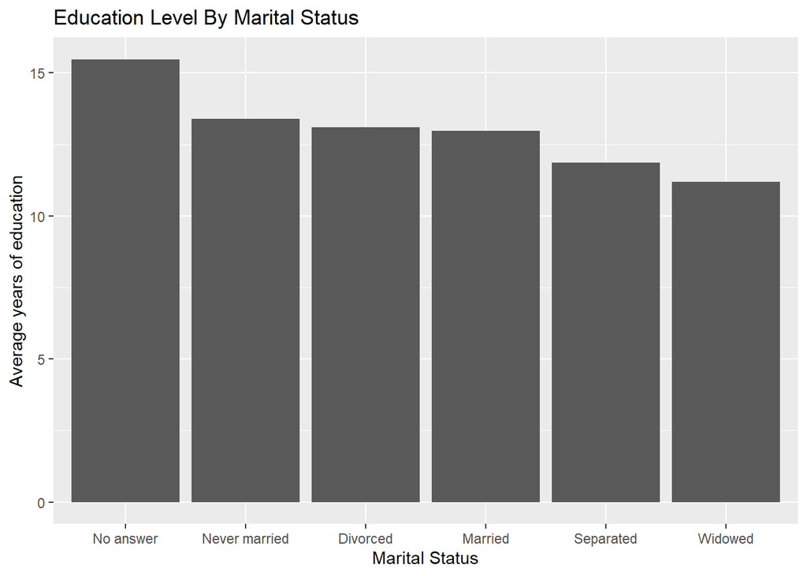

```r
data %>%
  filter(!is.na(`Marital status`)) %>%
  group_by(`Marital status`) %>%
  summarize(mean = mean(`Highest year of school completed`, na.rm=TRUE)) %>%
  ggplot(aes(x=reorder(`Marital status`, -mean), weight=mean)) +
  geom_bar() +
  labs(title="Education Level By Marital Status", x="Marital Status", y="Average years of education")
```

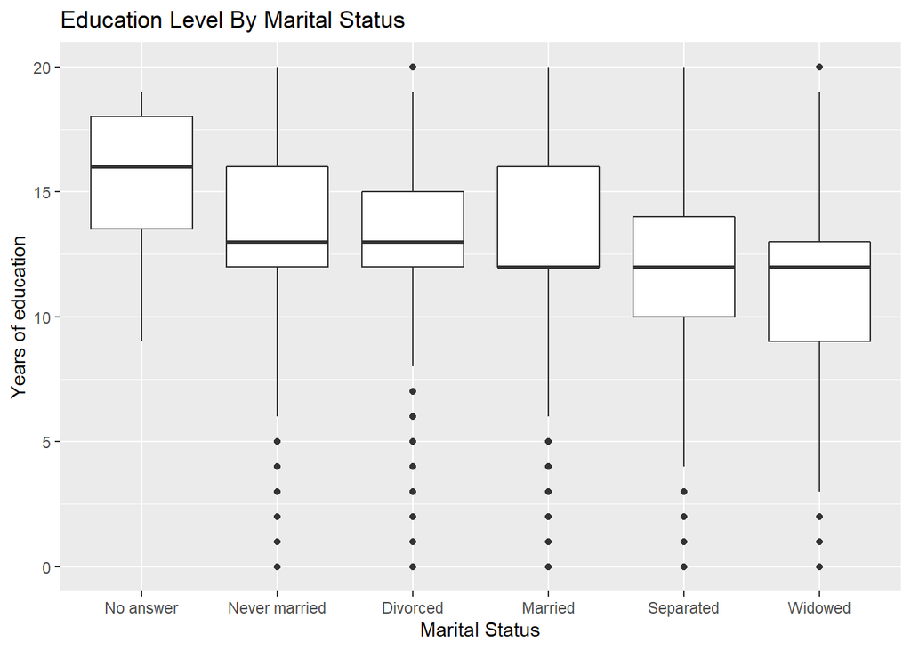

```r
data %>%
  filter(!is.na(`Marital status`)) %>%
  filter(!is.na(`Highest year of school completed`)) %>%
  ggplot(aes(x=factor(`Marital status`, levels=pull(aveEdu, `Marital status`)), y=`Highest year of school completed`)) +
  geom_boxplot() +
  labs(title="Education Level By Marital Status", x="Marital Status", y="Years of education")
```

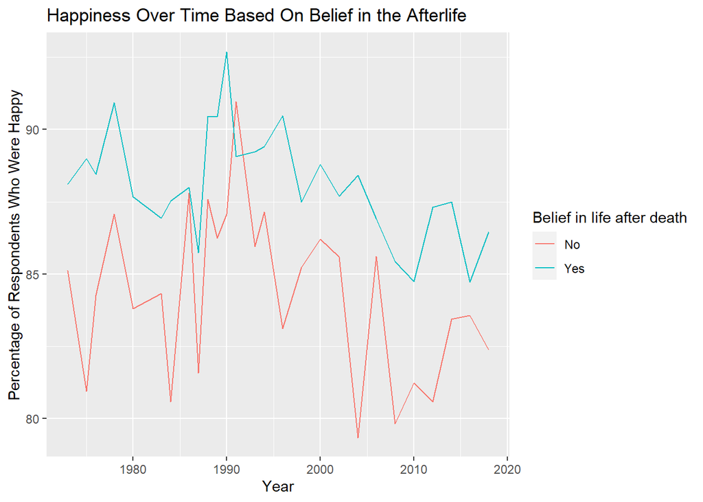

```r
yesno <- c("Yes", "No")

data %>%
  filter(`Belief in life after death` %in% yesno) %>%
  mutate(Happy = ifelse(`General happiness` == "Very happy" |
                        `General happiness` == "Pretty happy", "Happy", "Unhappy")) %>%
  group_by(`Gss year for this respondent`, `Belief in life after death`) %>%
  summarize(`Percentage happy` = 100 * length(Happy[which(Happy == "Happy")]) / n(), .groups="drop_last") %>%
  ggplot(aes(x=`Gss year for this respondent`, y=`Percentage happy`, color=`Belief in life after death`)) +
  geom_line() +
  labs(title="Happiness Over Time Based On Belief in the Afterlife", x="Year", y="Percentage of Respondents Who Were Happy")
```

```r
noData <- data %>%
  filter(`Belief in life after death` %in% yesno) %>%
  mutate(Happy = ifelse(`General happiness` == "Very happy" |
                        `General happiness` == "Pretty happy", "Happy", "Unhappy")) %>%
  group_by(`Gss year for this respondent`, `Belief in life after death`) %>%
  summarize(`Percentage happy` = 100 * length(Happy[which(Happy == "Happy")]) / n(),
            .groups="drop_last") %>%
  filter(`Belief in life after death` == "No")

yesData <- data %>%
  filter(`Belief in life after death` %in% yesno) %>%
  mutate(Happy = ifelse(`General happiness` == "Very happy" |
                          `General happiness` == "Pretty happy", "Happy", "Unhappy")) %>%
  group_by(`Gss year for this respondent`, `Belief in life after death`) %>%
  summarize(`Percentage happy` = 100 * length(Happy[which(Happy == "Happy")]) / n(),
            .groups="drop_last") %>%
  filter(`Belief in life after death` == "Yes")

changeInNo <- (last(noData %>% pull(`Percentage happy`)) - first(noData %>% pull(`Percentage happy`))) /
  (last(noData %>% pull(`Gss year for this respondent`)) - first(noData %>% pull(`Gss year for this respondent`))) * 100
changeInYes <- (last(yesData %>% pull(`Percentage happy`)) - first(yesData %>% pull(`Percentage happy`))) /
  (last(yesData %>% pull(`Gss year for this respondent`)) - first(yesData %>% pull(`Gss year for this respondent`))) * 100
percentChangeInHappiness <- c(changeInNo, changeInYes)
names(percentChangeInHappiness) <- c("Don't believe in afterlife", "Believe in afterlife")

percentChangeInHappiness
```

```
## Don't believe in afterlife       Believe in afterlife
##                  -6.098774                  -3.673504
```

This investigation looks at how people’s belief in life after death has affected their happiness over time. A person was considered to be `Happy` if they responded to the questionnaire that they considered themselves to be either `Very happy` or `Pretty happy`.